# BIOL 3100 Course Exam 4

May 5, 2021

### I. Load the data FacultySalaries_1995.csv

College faculty salaries and total compensation from 1995, by Ranks, Tier, and State College faculty have 3 ranks: Assistant (not tenured), Associate (tenured), and Full (been around forever or something). College “Tier” refers to the amount of funding devoted to research vs the amount of funding for teaching, with Tier I being universities that spend more on research than teaching and award PhD degrees.

```
## # A tibble: 6 × 17
##   FedID UnivName  State Tier  AvgFullProfSala… AvgAssocProfSal… AvgAssistProfSa…
##   <dbl> <chr>     <chr> <chr>            <dbl>            <dbl>            <dbl>
## 1  1061 Alaska P… AK    IIB                454              382              362
## 2  1063 Univ.Ala… AK    I                  686              560              432
## 3  1065 Univ.Ala… AK    IIA                533              494              329
## 4 11462 Univ.Ala… AK    IIA                612              507              414
## 5  1002 Alabama … AL    IIA                442              369              310
## 6  1004 Universi… AL    IIA                441              385              310
## # … with 10 more variables: AvgProfSalaryAll <dbl>, AvgFullProfComp <dbl>,
## #   AvgAssocProfComp <dbl>, AvgAssistProfComp <dbl>, AvgProfCompAll <dbl>,
## #   NumFullProfs <dbl>, NumAssocProfs <dbl>, NumAssistProfs <dbl>,
## #   NumInstructors <dbl>, NumFacultyAll <dbl>
```

Looks a little messy. In order to replicate Figure 1 we will need to clean the data.

```
## # A tibble: 6 × 6
##   FedID UnivName                  State Tier  Rank   Salary
##   <dbl> <chr>                     <chr> <chr> <chr>   <dbl>
## 1  1061 Alaska Pacific University AK    IIB   Full      454
## 2  1061 Alaska Pacific University AK    IIB   Assoc     382
## 3  1061 Alaska Pacific University AK    IIB   Assist    362
## 4  1063 Univ.Alaska-Fairbanks     AK    I     Full      686
## 5  1063 Univ.Alaska-Fairbanks     AK    I     Assoc     560
## 6  1063 Univ.Alaska-Fairbanks     AK    I     Assist    432
```

Oh, much better.

Next, we will remake Figure 1

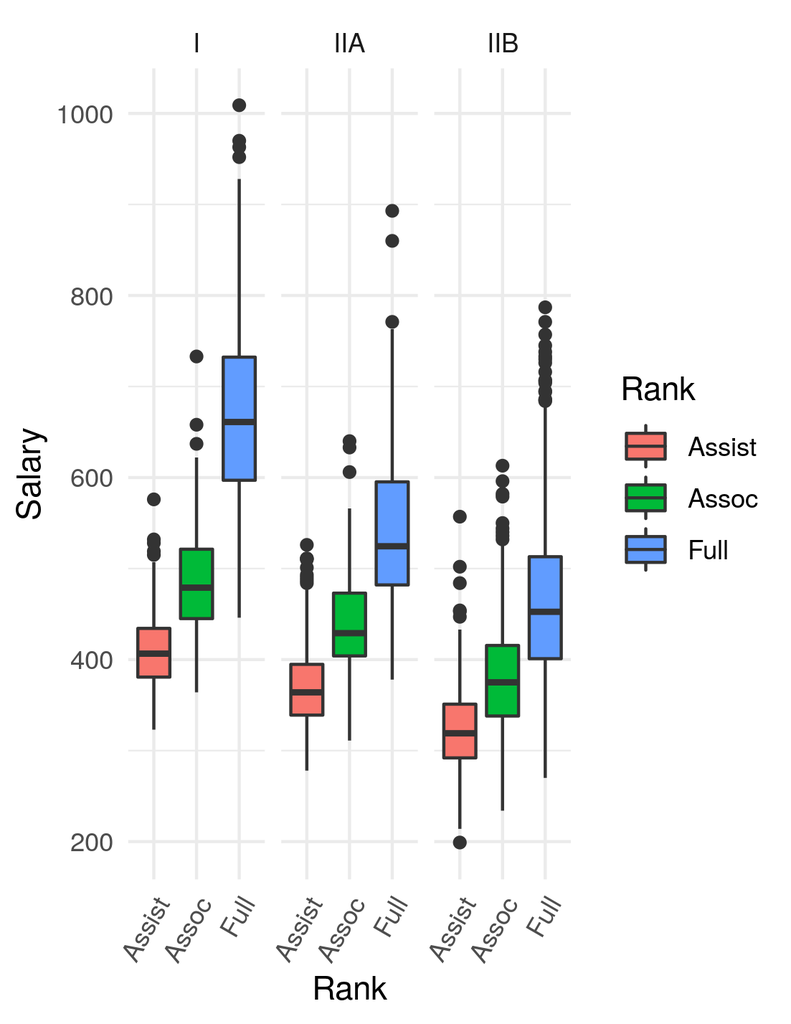

##### Our remake

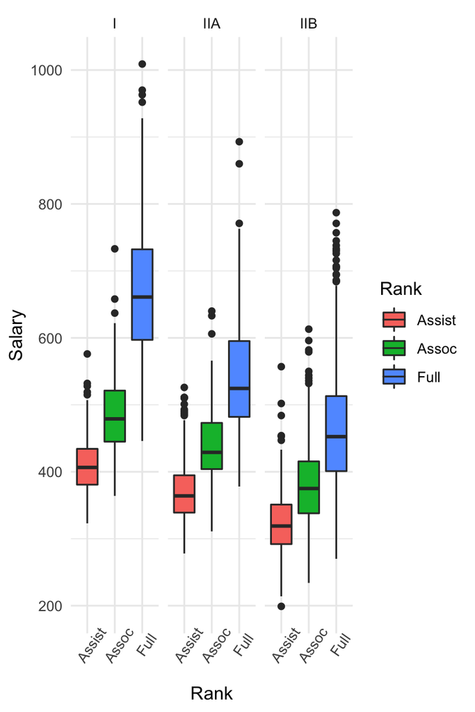

Not too shabby.

### II. Export an ANOVA table to a file called “Salary_ANOVA_Summary.txt”

The ANOVA model should test the influence of “State”, “Tier”, and “Rank” on “Salary” but should NOT include any interactions between those predictors.

```r
model <- lm(Salary ~ State + Tier + Rank, data=fs4)
sstable <- aov(model, type = 3)
sstable
```

```
## Call:
##    aov(formula = model, type = 3)
##
## Terms:
##                    State     Tier     Rank Residuals
## Sum of Squares   5667124  7072361 16526626  11987752
## Deg. of Freedom       50        2        2      3297
##
## Residual standard error: 60.2989
## Estimated effects may be unbalanced
## 128 observations deleted due to missingness
```

### III. The rest of the test uses another data set: The “Juniper_Oils.csv” data. Load the data and take a look.

It’s not exactly tidy either. Get used to that. It’s real data collected as part of a collaboration between Young Living Inc. and UVU Microbiology. A number of dead cedar trees were collected and the chemical composition of their essential oil content was measured. The hypothesis was that certain chemicals would degrade over time since they died in fires. So there are a bunch of columns for chemical compounds, and a column for “YearsSinceBurn.” The values under each chemical are Mass-Spec concentrations.

Let’s look at the data first

```
## # A tibble: 34 × 41
##    SampleID     Project     Amplicon Tree_Species    BurnYear Latitude Longitude
##    <chr>        <chr>       <chr>    <chr>              <dbl>    <dbl>     <dbl>
##  1 LOG-16S-SL12 JuniperLogs 16S      Juniperus oste…     2018     41.6     -114.
##  2 LOG-16S-SL11 JuniperLogs 16S      Juniperus oste…     2017     40.9     -113.
##  3 LOG-16S-CC5  JuniperLogs 16S      Juniperus oste…     2016     37.6     -113.
##  4 LOG-16S-SL9  JuniperLogs 16S      Juniperus oste…     2014     39.9     -113.
##  5 LOG-16S-SL8  JuniperLogs 16S      Juniperus oste…     2013     41.5     -114.
##  6 LOG-16S-SL7  JuniperLogs 16S      Juniperus oste…     2012     40.8     -112.
##  7 LOG-16S-SL6  JuniperLogs 16S      Juniperus oste…     2011     40.0     -113.
##  8 LOG-16S-SL4  JuniperLogs 16S      Juniperus oste…     2009     40.0     -113.
##  9 LOG-16S-SL3  JuniperLogs 16S      Juniperus oste…     2008     41.5     -114.
## 10 LOG-16S-SL2  JuniperLogs 16S      Juniperus oste…     2007     41.0     -113.
## # … with 24 more rows, and 34 more variables: Field_Office <chr>,
## #   BLM_Fire_Name <chr>, Tracking_Number <chr>, alpha-pinene <dbl>,
## #   para-cymene <dbl>, alpha-terpineol <dbl>, cedr-9-ene <dbl>,
## #   alpha-cedrene <dbl>, beta-cedrene <dbl>, cis-thujopsene <dbl>,
## #   alpha-himachalene <dbl>, beta-chamigrene <dbl>, cuparene <dbl>,
## #   compound 1 <dbl>, alpha-chamigrene <dbl>, widdrol <dbl>, cedrol <dbl>,
## #   beta-acorenol <dbl>, alpha-acorenol <dbl>, gamma-eudesmol <dbl>, …
```

Well, it’s time to tidy it up so we can reproduce Figure 2.

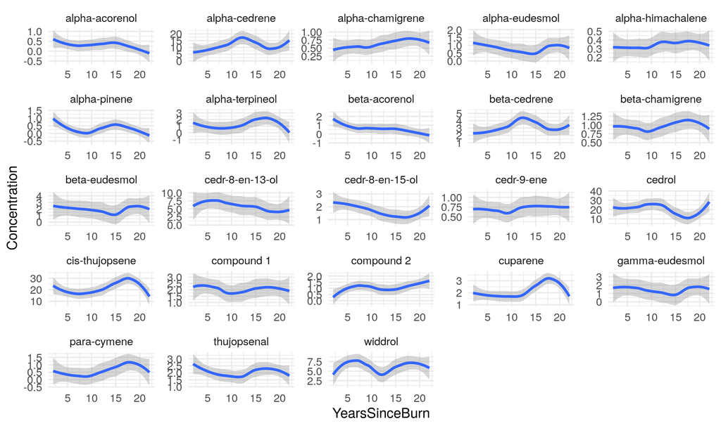

Here is our tidy data:

```
## Rows: 782
## Columns: 3
## $ YearsSinceBurn <dbl> 2, 2, 2, 2, 2, 2, 2, 2, 2, 2, 2, 2, 2, 2, 2, 2, 2, 2, 2…
## $ ChemicalID     <chr> "alpha-pinene", "para-cymene", "alpha-terpineol", "cedr…
## $ Concentration  <dbl> 0.6, 0.4, 2.3, 0.2, 1.9, 1.2, 25.9, 0.2, 0.4, 1.8, 0.7,…
```

That looks much better.

### IV. Make a graph of the following:

```
    x = YearsSinceBurn
    y = Concentration
    facet = ChemicalID (use free y-axis scales)
```

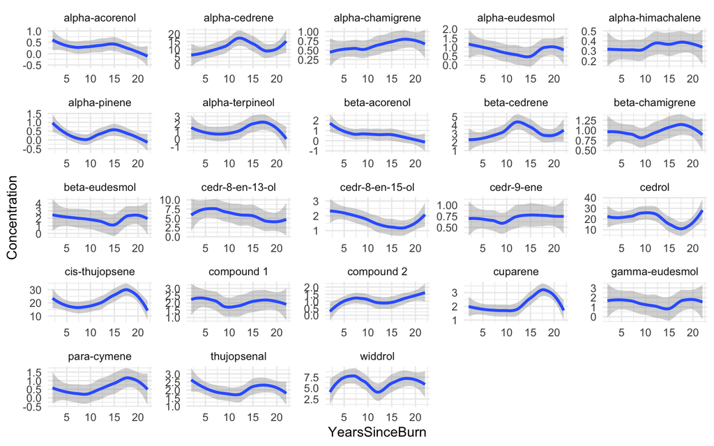

### V. Finally, we will use a generalized linear model to find which chemicals show concentrations that are significantly (significant, as in P < 0.05) affected by “Years Since Burn”.

##### I’ll show you what I mean. Here is the data frame I need you to produce from your glm model:

```
      A tibble: 6 x 5
      term                          estimate std.error statistic  p.value
      <chr>                            <dbl>     <dbl>     <dbl>    <dbl>
      1 alpha-cedrene                    7.88      1.93       4.08 4.97e- 5
      2 cedr-8-en-13-ol                  7.62      1.93       3.95 8.72e- 5
      3 cedrol                          22.5       1.93      11.7  5.12e-29
      4 cis-thujopsene                  17.3       1.93       8.95 2.93e-18
      5 widdrol                          5.82      1.93       3.01 2.69e- 3
      6 cis-thujopsene:YearsSinceBurn    0.332     0.141      2.35 1.90e- 2
```

Let’s see how we did

```
## # A tibble: 6 × 5
##   term                          estimate std.error statistic  p.value
##   <chr>                            <dbl>     <dbl>     <dbl>    <dbl>
## 1 alpha-cedrene                    7.88      1.93       4.08 4.97e- 5
## 2 cedr-8-en-13-ol                  7.62      1.93       3.95 8.72e- 5
## 3 cedrol                          22.5       1.93      11.7  5.12e-29
## 4 cis-thujopsene                  17.3       1.93       8.95 2.93e-18
## 5 widdrol                          5.82      1.93       3.01 2.69e- 3
## 6 cis-thujopsene:YearsSinceBurn    0.332     0.141      2.35 1.90e- 2
```